# Project2

Spencer Muncey and Chenchao Zang

October 2, 2015

# Health Insurance and Hours Worked By Wives

This data set was referenced in a September 1998 article written by Craig Olson in the *Journal of Applied Econometrics*. The data was used to determine the validity of the hypothesis that wives who do not have health insurance through their husband’s employer are more likely to work full-time to get health insurance than wives who are covered by their husband’s health insurance.

Here is the article in its entirety if you would like to read it: 1998 Olson Journal of Applied Econometrics

## The data set

The data first had to be extracted, transformed, and then loaded into the Oracle database. Here is the code that performs that ETL:

```
#Before running this R file make sure you set you working directory to where the CSV file located.

file_path <- "HI.csv"

df <- read.csv(file_path, stringsAsFactors = FALSE)

Newdf <- subset(df, select = c("whrswk","hhi","whi","hhi2","education","race","hispanic","experience","kidslt6","kids618","husby","region"))

#head(Newdf)

# Replace "." (i.e., period) with "_" in the column names.
names(Newdf) <- gsub("\\.+", "_", names(Newdf))

str(Newdf) # Uncomment this and  run just the lines to here to get column types to use for getting the list of measures.

measures <- c("whrswk", "experience", "kidslt6", "kids618", "husby")

# Get rid of special characters in each column.
# Google ASCII Table to understand the following:
for(n in names(Newdf)) {
    Newdf[n] <- data.frame(lapply(Newdf[n], gsub, pattern="[^ -~]",replacement= ""))
}

dimensions <- setdiff(names(Newdf), measures)
#dimensions
if( length(measures) > 1 || ! is.na(dimensions)) {
  for(d in dimensions) {
    # Get rid of " and ' in dimensions.
    Newdf[d] <- data.frame(lapply(Newdf[d], gsub, pattern="[\"']",replacement= ""))
    # Change & to and in dimensions.
    Newdf[d] <- data.frame(lapply(Newdf[d], gsub, pattern="&",replacement= " and "))
    # Change : to ; in dimensions.
    Newdf[d] <- data.frame(lapply(Newdf[d], gsub, pattern=":",replacement= ";"))
  }
}


# Get rid of all characters in measures except for numbers, the - sign, and period.dimensions
if( length(measures) > 1 || ! is.na(measures)) {
  for(m in measures) {
    Newdf[m] <- data.frame(lapply(Newdf[m], gsub, pattern="[^--.0-9]",replacement= ""))
  }
}

write.csv(Newdf, paste(gsub(".csv", "", file_path), ".reformatted.csv", sep=""), row.names=FALSE, na = "")

tableName <- gsub(" +", "_", gsub("[^A-z, 0-9, ]", "", gsub(".csv", "", file_path)))
sql <- paste("CREATE TABLE", tableName, "(\n-- Change table_name to the table name you want.\n")
if( length(measures) > 1 || ! is.na(dimensions)) {
  for(d in dimensions) {
    sql <- paste(sql, paste(d, "varchar2(4000),\n"))
  }
}
if( length(measures) > 1 || ! is.na(measures)) {
  for(m in measures) {
    if(m != tail(measures, n=1)) sql <- paste(sql, paste(m, "number(38,4),\n"))
    else sql <- paste(sql, paste(m, "number(38,4)\n"))
  }
}
sql <- paste(sql, ");")
cat(sql)
```

The data set is from the March 1993 US Current Population Survey. Here is a summary of that data set:

```r
require("jsonlite")
require("RCurl")
```

```r
# Change the USER and PASS below to be your UTEid
df <- data.frame(fromJSON(getURL(URLencode('129.152.144.84:5001/rest/native/?query="select * from hi"'),httpheader=c(DB='jdbc:oracle:thin:@129.152.144.84:1521/PDBF15DV.usuniversi01134.oraclecloud.internal', USER='cs329e_cz4795', PASS='orcl_cz4795', MODE='native_mode', MODEL='model', returnDimensions = 'False', returnFor = 'JSON'), verbose = TRUE), ))
summary(df)
```

```
##   HHI         WHI         HHI2            EDUCATION       RACE
##  no :11219   no :13961   no : 8696   <9years   :1122   black: 1241
##  yes:11053   yes: 8311   yes:13576   >16years  :1440   other:  171
##                                      12years   :8677   white:20860
##                                      13-15years:5790
##                                      16years   :3472
##                                      9-11years :1771
##  HISPANIC             REGION         WHRSWK        EXPERIENCE
##  no :20601   northcentral:5491   Min.   : 0.00   Min.   :-1.00
##  yes: 1671   other       :5170   1st Qu.: 0.00   1st Qu.:14.00
##              south       :6778   Median :35.00   Median :21.00
##              west        :4833   Mean   :25.57   Mean   :22.94
##                                  3rd Qu.:40.00   3rd Qu.:31.00
##                                  Max.   :90.00   Max.   :51.00
##     KIDSLT6          KIDS618          HUSBY
##  Min.   :0.0000   Min.   :0.000   Min.   :  0.0
##  1st Qu.:0.0000   1st Qu.:0.000   1st Qu.:  7.5
##  Median :0.0000   Median :0.000   Median : 25.0
##  Mean   :0.3494   Mean   :0.691   Mean   : 27.1
##  3rd Qu.:1.0000   3rd Qu.:1.000   3rd Qu.: 40.0
##  Max.   :5.0000   Max.   :8.000   Max.   :183.7
```

```r
head(df)
```

```
##   HHI WHI HHI2  EDUCATION  RACE HISPANIC       REGION WHRSWK EXPERIENCE
## 1  no  no   no 13-15years white       no northcentral      0       13.0
## 2  no yes   no 13-15years white       no northcentral     50       24.0
## 3 yes  no  yes    12years white       no northcentral     40       43.0
## 4  no yes  yes 13-15years white       no northcentral     40       17.0
## 5 yes  no  yes  9-11years white       no northcentral      0       44.5
## 6 yes yes  yes    12years white       no northcentral     40       32.0
##   KIDSLT6 KIDS618  HUSBY
## 1       2       1 11.960
## 2       0       1  1.200
## 3       0       0 31.275
## 4       0       1  9.000
## 5       0       0  0.000
## 6       0       0 15.690
```

A detailed explanation of each column in the data set:

- WHRSWK - Hours worked per week by wife
- HHI - Is the wife covered by the husband’s health insurance? “yes”, “no”
- WHI - Does the wife have health insurnace through her job? “yes”, “no”
- HHI2 - Does the husband has health insurance through his own job? “yes”, “no”
- education - Education level of the wife, “<9years”, “9-11years”, “12years”, “13-15years”, “16years”, “>16years”
- race - Race of wife: “white”, “black”, “other”
- hispanic - Is the wife Hispanic? “yes”, “no”
- region - Region where wife and husband live: “other”, “northcentral”, “south”, “west”
- experience - Years of husbands potential work experience
- kidslt6 - Number of kids under age of 6
- kids618 - Number of kids 6–18 years old
- husby - Husband’s income in thousands of dollars

### Plot 1: Average Number of Children per Wife’s Education Level and Husband’s Income

```
##
## > require(tidyr)
```

```
##
## > require(dplyr)
```

```
##
## > require(ggplot2)
```

```
##
## > Plot1_df <- df
##
## > Plot1_df$EDUCATION <- factor(df$EDUCATION, levels = c("<9years",
## +     "9-11years", "12years", "13-15years", "16years", ">16years"),
## +     labels  .... [TRUNCATED]
##
## > Plot1_df <- Plot1_df %>% group_by(EDUCATION, HUSBY) %>%
## +     summarise(mean_kids = mean(KIDSLT6 + KIDS618))
##
## > ggplot() + coord_cartesian() + scale_x_continuous() +
## +     scale_y_continuous() + facet_grid(. ~ EDUCATION) + labs(title = "Average Number of Chil ..." ... [TRUNCATED]
```

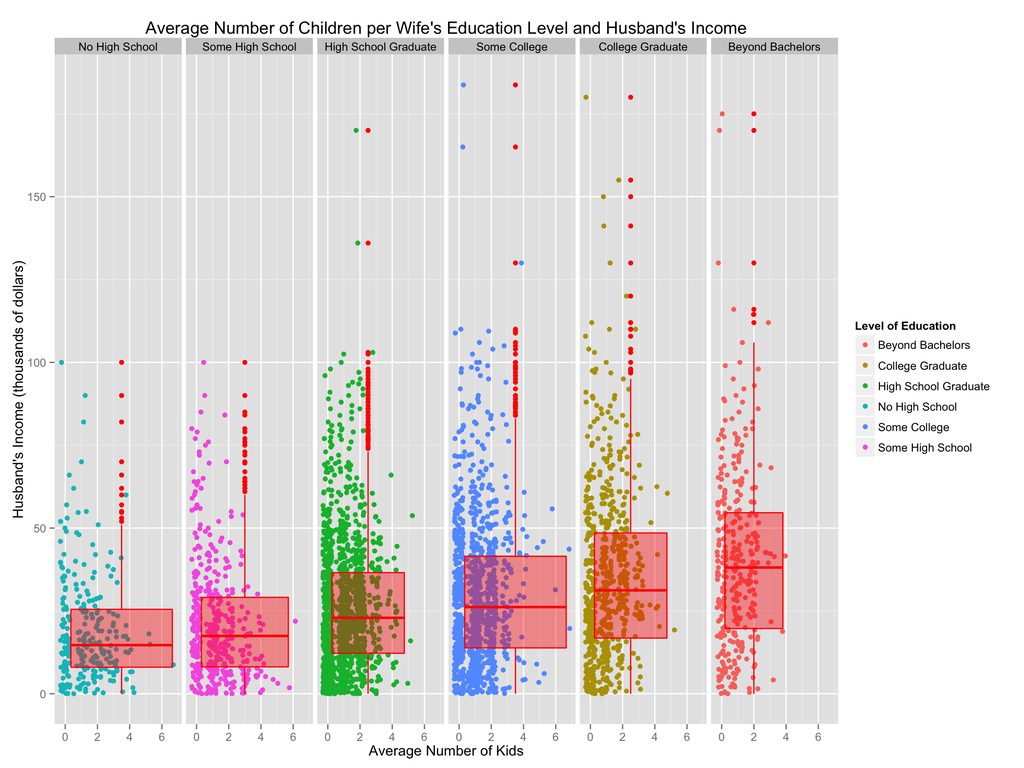

```r
source("../02 Data Wrangling/Project2_Plot1_df.r", echo = TRUE)
```

This plot was originally created to verify the hypothesis that there is an inverse relationship between the husband’s income and average children as well as an inverse relationship between the wife’s education level and the average number of children. In other words, the more educated a woman is, and the higher the husband’s income, the less children they have on average.

Data Wrangling R Workflow to produce the dataframe that powers this plot:

```
Plot1_df <- df %>% group_by (EDUCATION, HUSBY) %>% summarise(mean_kids = mean(KIDSLT6 + KIDS618))
```

### Plot 2: Top and Bottom 10 Percent of Husband’s Work Experience

```
##
## > require(tidyr)
##
## > require(dplyr)
##
## > require(ggplot2)
##
## > Plot2_df <- df %>% mutate(EXPERIENCE_PERCENT = cume_dist(EXPERIENCE)) %>%
## +     filter(EXPERIENCE_PERCENT <= 0.1 | EXPERIENCE_PERCENT >=
## +         .... [TRUNCATED]
##
## > ggplot() + coord_cartesian() + scale_x_continuous() +
## +     scale_y_continuous() + labs(title = "Top & Bottom 10 percent of Husband's Work Experien ..." ... [TRUNCATED]
```

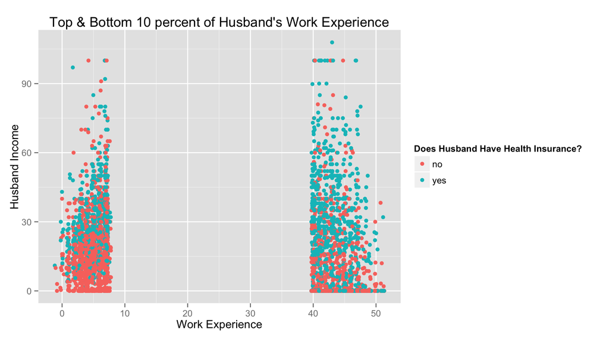

```r
source("../02 Data Wrangling/Project2_Plot2_df.r", echo = TRUE)
```

This plot looks at how likely the husband is to have health insurance based on how much work experience he has and his income level.

Data Wrangling R Workflow to produce the dataframe that powers this plot:

```
Plot2_df <- df %>% mutate(EXPERIENCE_PERCENT = cume_dist(EXPERIENCE)) %>% filter(EXPERIENCE_PERCENT  <= .1 | EXPERIENCE_PERCENT  >= .9)
```

### Plot 3: Influence of Number of Kids and No Health Insurance from Husband on Hours Worked by Wives

```
##
## > require(tidyr)
##
## > require(dplyr)
##
## > require(ggplot2)
##
## > Plot3_df <- df %>% select(HHI, KIDSLT6, KIDS618, WHRSWK) %>%
## +     filter(HHI == "no") %>% mutate(TOTAL_KIDS = KIDSLT6 + KIDS618)
##
## > ggplot() + coord_cartesian() + scale_x_continuous() +
## +     scale_y_continuous() + facet_grid(. ~ TOTAL_KIDS, labeller = label_both) +
## +     labs( .... [TRUNCATED]
```

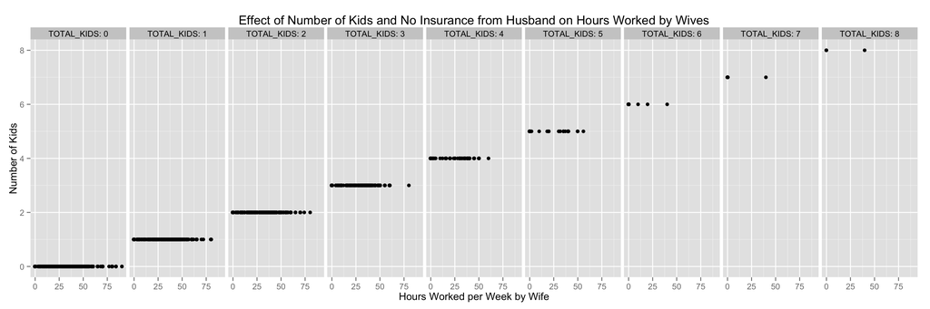

```r
source("../02 Data Wrangling/Project2_Plot3_df.r", echo = TRUE)
```

Data Wrangling R Workflow to produce the dataframe that powers this plot:

```
Plot3_df <- df %>% select(HHI, KIDSLT6, KIDS618, WHRSWK) %>% filter(HHI == "no") %>% mutate(TOTAL_KIDS = KIDSLT6 + KIDS618)
```